# Bayesian Data Analysis Final Project: Fall 2023

Prisha Bhamre

2023-12-14

```r
# Load packages
library(mlbench)
library(ggplot2)
library(rstanarm)
library(bayesplot)
library(bayesrules)
library(tidyverse)
library(tidybayes)
library(corrplot)
library(e1071)
library(gtsummary)
library(dplyr)
library(janitor)
library(broom.mixed)
library(rpart)
library(rpart.plot)
```

### Explore the Data

**Pima Indians Diabetes Database**

```r
# utilizing Preprocessing of the Pima Indian dataset completed by Aki Vehtari, Jonah Gabry, and Ben Goodrich at https://avehtari.github.io/modelselection/diabetes.html#4_A_Bayesian_logistic_regression_model
data(PimaIndiansDiabetes)
dim(PimaIndiansDiabetes)
```

```
[1] 768   9
```

```r
head(PimaIndiansDiabetes)
```

|  | pregnant | glucose | pressure | triceps | insulin | mass | pedigree | age | diabetes |
| --- | --- | --- | --- | --- | --- | --- | --- | --- | --- |
| 1 | 6 | 148 | 72 | 35 | 0 | 33.6 | 0.627 | 50 | pos |
| 2 | 1 | 85 | 66 | 29 | 0 | 26.6 | 0.351 | 31 | neg |
| 3 | 8 | 183 | 64 | 0 | 0 | 23.3 | 0.672 | 32 | pos |
| 4 | 1 | 89 | 66 | 23 | 94 | 28.1 | 0.167 | 21 | neg |
| 5 | 0 | 137 | 40 | 35 | 168 | 43.1 | 2.288 | 33 | pos |
| 6 | 5 | 116 | 74 | 0 | 0 | 25.6 | 0.201 | 30 | neg |

```r
summary(PimaIndiansDiabetes)
```

```
    pregnant         glucose         pressure         triceps         insulin
 Min.   : 0.000   Min.   :  0.0   Min.   :  0.00   Min.   : 0.00   Min.   :  0.0
 1st Qu.: 1.000   1st Qu.: 99.0   1st Qu.: 62.00   1st Qu.: 0.00   1st Qu.:  0.0
 Median : 3.000   Median :117.0   Median : 72.00   Median :23.00   Median : 30.5
 Mean   : 3.845   Mean   :120.9   Mean   : 69.11   Mean   :20.54   Mean   : 79.8
 3rd Qu.: 6.000   3rd Qu.:140.2   3rd Qu.: 80.00   3rd Qu.:32.00   3rd Qu.:127.2
 Max.   :17.000   Max.   :199.0   Max.   :122.00   Max.   :99.00   Max.   :846.0
      mass          pedigree           age        diabetes
 Min.   : 0.00   Min.   :0.0780   Min.   :21.00   neg:500
 1st Qu.:27.30   1st Qu.:0.2437   1st Qu.:24.00   pos:268
 Median :32.00   Median :0.3725   Median :29.00
 Mean   :31.99   Mean   :0.4719   Mean   :33.24
 3rd Qu.:36.60   3rd Qu.:0.6262   3rd Qu.:41.00
 Max.   :67.10   Max.   :2.4200   Max.   :81.00
```

```r
# removing those observation rows with 0 in variables where 0s wer inputted for missing values
for (i in 2:6) {
      PimaIndiansDiabetes <- PimaIndiansDiabetes[-which(PimaIndiansDiabetes[, i] == 0), ]
}

PimaIndiansDiabetes$isDiabetic <- ifelse(PimaIndiansDiabetes$diabetes == "pos", 1, 0)
PimaIndiansDiabetes[, c(9, 10)] <- PimaIndiansDiabetes[, c(10, 9)]
colnames(PimaIndiansDiabetes)[c(9, 10)] <- colnames(PimaIndiansDiabetes)[c(10, 9)]

#create a duplicate data set to scale
scaled_PIdiabetes <- PimaIndiansDiabetes
# scale the covariates for easier comparison of coefficient posteriors
for (i in 1:8) {
  scaled_PIdiabetes[i] <- scale(PimaIndiansDiabetes[i])
}

dim(scaled_PIdiabetes)
```

```
[1] 392  10
```

```r
summary(scaled_PIdiabetes)
```

```
  pregnant.pregnant    glucose.glucose     pressure.pressure    triceps.triceps
 Min.   :-1.027899   Min.   :-2.1589717   Min.   :-3.734229   Min.   :-2.105793
 1st Qu.:-0.716511   1st Qu.:-0.7656174   1st Qu.:-0.693278   1st Qu.:-0.774542
 Median :-0.405123   Median :-0.1175457   Median :-0.053078   Median :-0.013827
 Mean   : 0.000000   Mean   : 0.0000000   Mean   : 0.000000   Mean   : 0.000000
 3rd Qu.: 0.529042   3rd Qu.: 0.6601404   3rd Qu.: 0.587122   3rd Qu.: 0.746888
 Max.   : 4.265702   Max.   : 2.4423377   Max.   : 3.147923   Max.   : 3.219211
   insulin.insulin        mass.mass       pedigree.pedigree        age.age
 Min.   :-1.195339   Min.   :-2.118234   Min.   :-1.267905   Min.   :-0.967063
 1st Qu.:-0.667326   1st Qu.:-0.666826   1st Qu.:-0.733154   1st Qu.:-0.771000
 Median :-0.257116   Median : 0.016190   Median :-0.212875   Median :-0.378873
 Mean   : 0.000000   Mean   : 0.000000   Mean   : 0.000000   Mean   : 0.000000
 3rd Qu.: 0.285623   3rd Qu.: 0.571140   3rd Qu.: 0.474558   3rd Qu.: 0.503413
 Max.   : 5.805571   Max.   : 4.839986   Max.   : 5.490650   Max.   : 4.914842
   isDiabetic     diabetes
 Min.   :0.0000   neg:262
 1st Qu.:0.0000   pos:130
 Median :0.0000
 Mean   :0.3316
 3rd Qu.:1.0000
 Max.   :1.0000
```

Why I scaled variables: When covariates are on different scales, their coefficients represent changes in the outcome variable per unit change in the covariate. So it can be challenging to interpret and compare these coefficients directly, which is what was happening to me. By scaling the covariates, I transformed them to a common scale, making it easier to compare the magnitude and direction of their effects on the response variable. I was getting some results that weren’t clear for example, diabetes odds increasing by a certain percent for a one unit increase in a variable but they all had varing units it was hard to make a conclusion on the most significant predictor. So by searching the broader context and other research completed on this data set and I utilized this preprocessing of scaling to try to get easier to interpret results in the future analysis I do during this project.

### Plot the data:

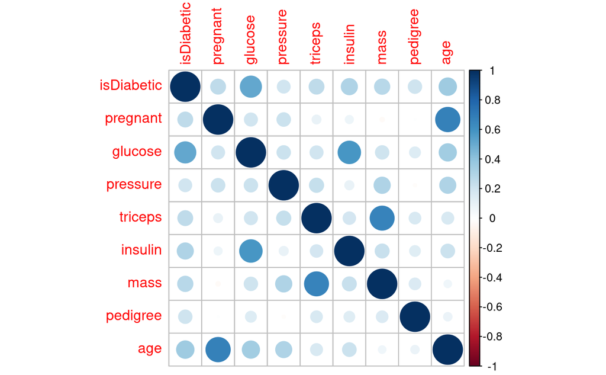

```r
corrplot(cor(scaled_PIdiabetes[, c(9,1:8)]))
```

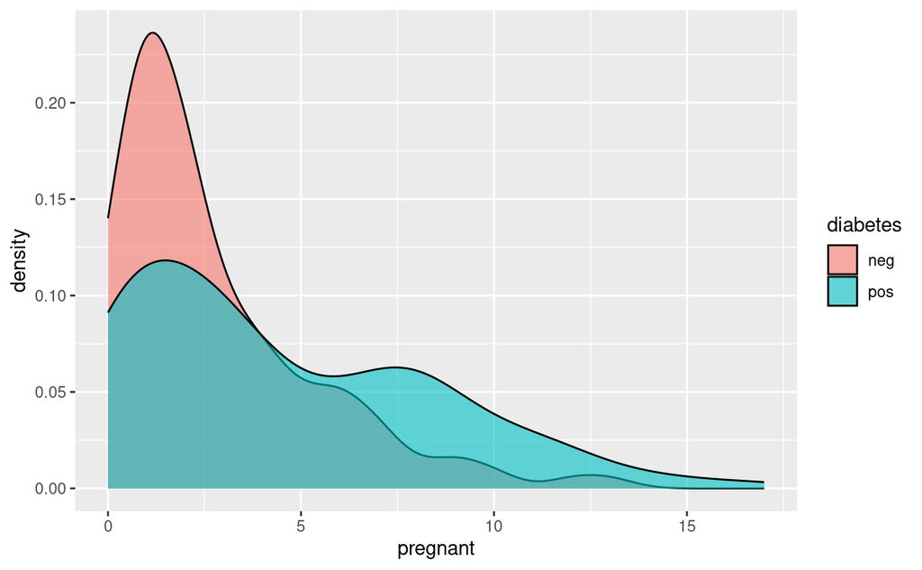

```r
ggplot(PimaIndiansDiabetes, aes(x = pregnant, fill = diabetes)) +
  geom_density(alpha = 0.6)
```

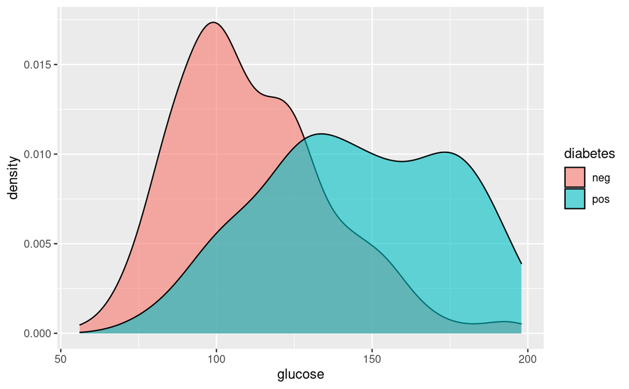

```r
ggplot(PimaIndiansDiabetes, aes(x = glucose, fill = diabetes)) +
  geom_density(alpha = 0.6)
```

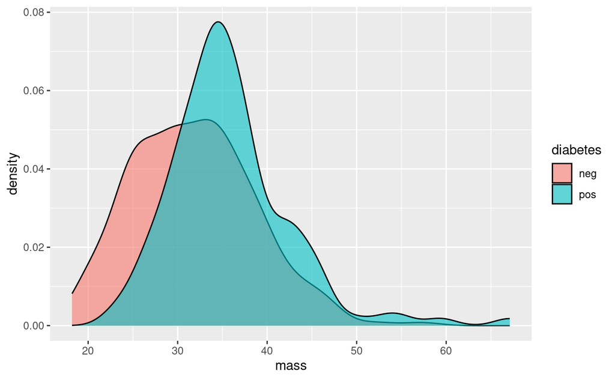

```r
ggplot(PimaIndiansDiabetes, aes(x = mass, fill = diabetes)) +
  geom_density(alpha = 0.6)
```

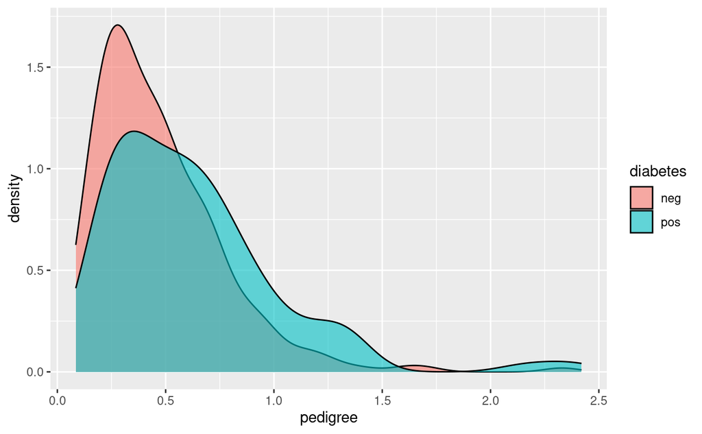

```r
ggplot(PimaIndiansDiabetes, aes(x = pedigree, fill = diabetes)) +
  geom_density(alpha = 0.6)
```

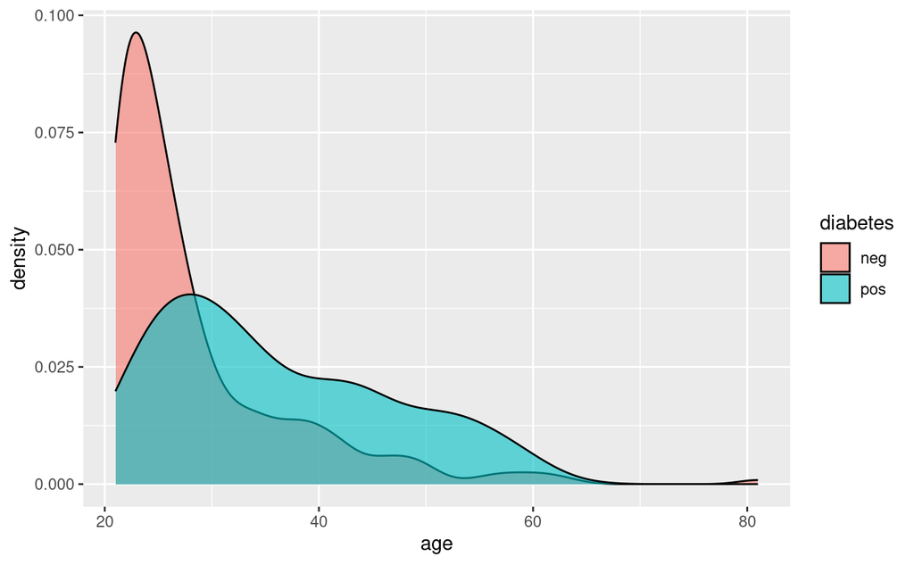

```r
ggplot(PimaIndiansDiabetes, aes(x = age, fill = diabetes)) +
  geom_density(alpha = 0.6)
```

### Create Bayesian Logistic Regression Model using stan_glm

**Specifify data model and priors**

$Y_i$ is a discrete variable which can only take two values, 0 or 1. Thus, the Bernoulli probability model is the best candidate for the diabetese data. Letting $π_i$ denote the probability of diabetes diagnoses for native person i. ,
$$\text{data: } Y_i \sim \text{Bern}(\pi_i) \quad \text{with} \quad
\log\left(\frac{\pi_i}{1 - \pi_i}\right) = \beta_0 + \beta_1 X_{i1}$$

Through my research I found through multiple corroborated sources that approximately 16 percent of native Americans are diagnosed as diabetic. Thus, we set the prior mean for $\beta_0$ on the log(odds) scale to -0.72:

$$\log(odds) = \log\left(\frac{0.16}{1 - 0.16}\right) \approx -0.72$$

and thus that the probability of diabetes for an average native American could be somewhere between 0.24 and 0.52:

$$\left(\frac{0.32}{1 + 0.32}, \frac{1.08}{1 + 1.08}\right) \approx (0.24,
0.52)$$
.

The $B_i$ is a broader prior compared to the first one and suggests less prior information, allowing for more variability in the parameters.

$$\text{priors: }
\begin{align*}
\beta_0 & \sim \mathcal{N}(-0.72, 0.40^2) \\
\beta_i & \sim \mathcal{N}(0, 2.5^2)
\end{align*}$$

**Simulate posterior:**

```r
(reg_formula <- formula(paste("isDiabetic ~", paste(names(scaled_PIdiabetes)[1:8], collapse = " + "))))
```

```
isDiabetic ~ pregnant + glucose + pressure + triceps + insulin +
    mass + pedigree + age
```

```r
scaled_diabetes_logit <- stan_glm(reg_formula,
                             data = scaled_PIdiabetes, family = binomial,
                             prior_intercept = normal(-0.72, 0.40),
                             prior = normal(0, 2.5, autoscale = TRUE),
                             chains = 4, iter = 5000*2, seed = 84735,
                             prior_PD = FALSE)
```

**Visual and numerical diagnostics of MCMC simulation:**

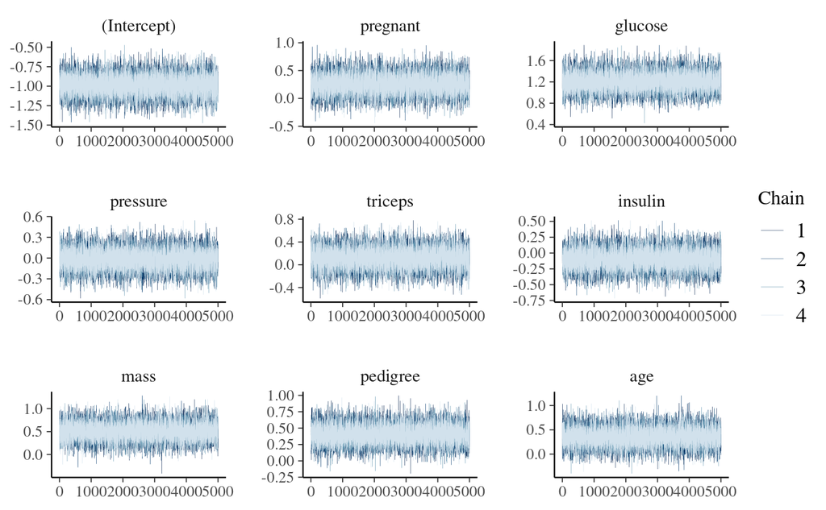

```r
mcmc_trace(scaled_diabetes_logit, size = 0.1)
```

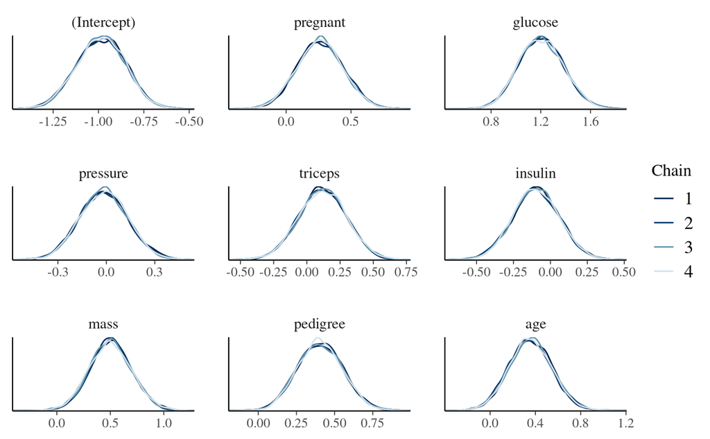

```r
mcmc_dens_overlay(scaled_diabetes_logit)
```

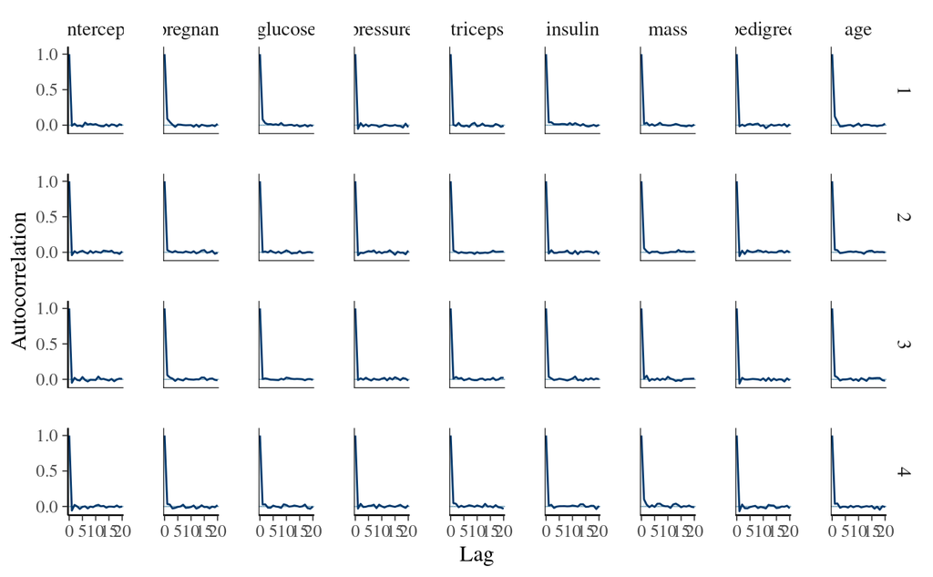

```r
mcmc_acf(scaled_diabetes_logit)
```

```r
neff_ratio(scaled_diabetes_logit)
```

```
(Intercept)    pregnant     glucose    pressure     triceps     insulin        mass
    1.05675     0.86420     0.89760     1.01970     0.91820     0.89115     0.84935
   pedigree         age
    1.06870     0.85965
```

```r
rhat(scaled_diabetes_logit)
```

```
(Intercept)    pregnant     glucose    pressure     triceps     insulin        mass
  1.0001093   0.9999545   0.9999573   1.0001185   1.0001049   0.9998611   1.0000226
   pedigree         age
  0.9999040   1.0000007
```

Interpretation: The trace plots shows a stable random walk, the density plots are unimodal and well behaved, ACF graphs show rapid decay, high eff ratios close to 1 and rhat values close to 1 and less than 1.01, which all indicate good mixing and convergence visually and numerically.

**Summarize and plot posteriors:**

```r
# Numerical summaries
diabetes_tidy <- tidy(scaled_diabetes_logit, effects = "fixed", conf.int = TRUE, conf.level = 0.80)

# Apply exp function to the estimate column to get the odds
diabetes_tidy_exp <- diabetes_tidy %>%
  mutate(exp_estimate = exp(estimate))

# Print the result
print(diabetes_tidy_exp)
```

| term | estimate | std.error | conf.low | conf.high | exp_estimate |
| --- | --- | --- | --- | --- | --- |
| (Intercept) | -0.98412162 | 0.1365425 | -1.16194262 | -0.8149351 | 0.3737674 |
| pregnant | 0.26079817 | 0.1793177 | 0.03044253 | 0.4937497 | 1.2979657 |
| glucose | 1.20157370 | 0.1832496 | 0.97583820 | 1.4373192 | 3.3253459 |
| pressure | -0.01575500 | 0.1510009 | -0.20696178 | 0.1755560 | 0.9843685 |
| triceps | 0.11904506 | 0.1801382 | -0.11369707 | 0.3507384 | 1.1264207 |
| insulin | -0.09768008 | 0.1581237 | -0.30155624 | 0.1062713 | 0.9069390 |
| mass | 0.50229803 | 0.1947071 | 0.25454862 | 0.7573478 | 1.6525144 |
| pedigree | 0.40338441 | 0.1522791 | 0.21420137 | 0.5971143 | 1.4968822 |
| age | 0.35540030 | 0.1908347 | 0.11421853 | 0.6003903 | 1.4267517 |

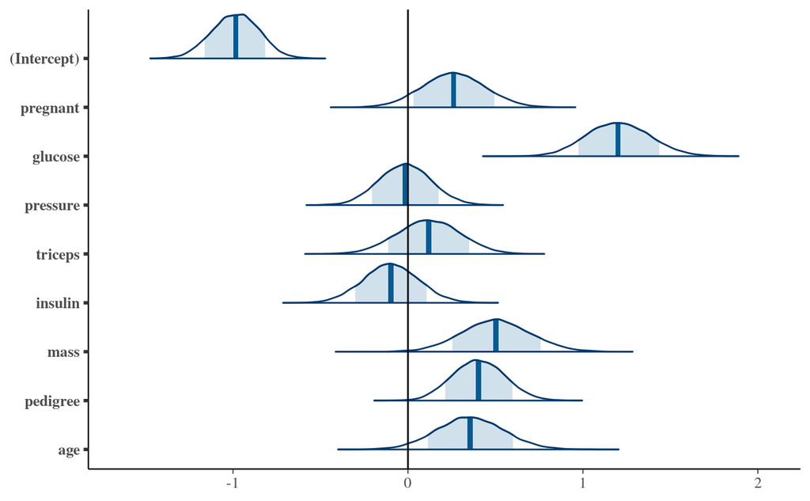

```r
#plot posterior distrubutions
pplot<-plot(scaled_diabetes_logit, "areas", prob = 0.80, prob_outer = 1)
pplot+ geom_vline(xintercept = 0)
```

Interpretation of the posterior summary on the odds scale:  
The estimate shows the posterior median log(odds).  
The exp_estimate column shows the odds.

The posterior median for the glucose coeff is 1.20 which is equivalent to the odds $e^{1.20} = 3.33$ which means the odds of diabetes more than triples with a one SCALED unit increase in glucose, when all other variables are controlled for. Thus, Glucose is a significant predictor of diabetes.

Blood pressure, tricep skin thickness, and insulin all have 80% posterior credible interval containing 0, which means they aren’t significant predictors of diabetes when controlling for the other variables. This is likely because they are closely assiciated with other variables like pressure with age, tricep skin thickness with mass, and insulin with glucose, thus the information it holds about diabetes is somewhat redundant in diabetes_logit model.

The diabetes pedigree function which calculates diabetes likelihood depending on the subject’s age and their diabetic family history. It along with body mass index, age, and pregnancy (likely indicating gestational diabetes that developed into diabetes) are good predictors of diabetes, when controlling for all other variables.

The scaled data has served its purpose for making our interpretation task easier!

### Prediction & classification:

lets return to using the unscaled data to complete prediction and classification with unscaled values so its easier to input values for the predictors and remake the logistic model with the unscaled data.

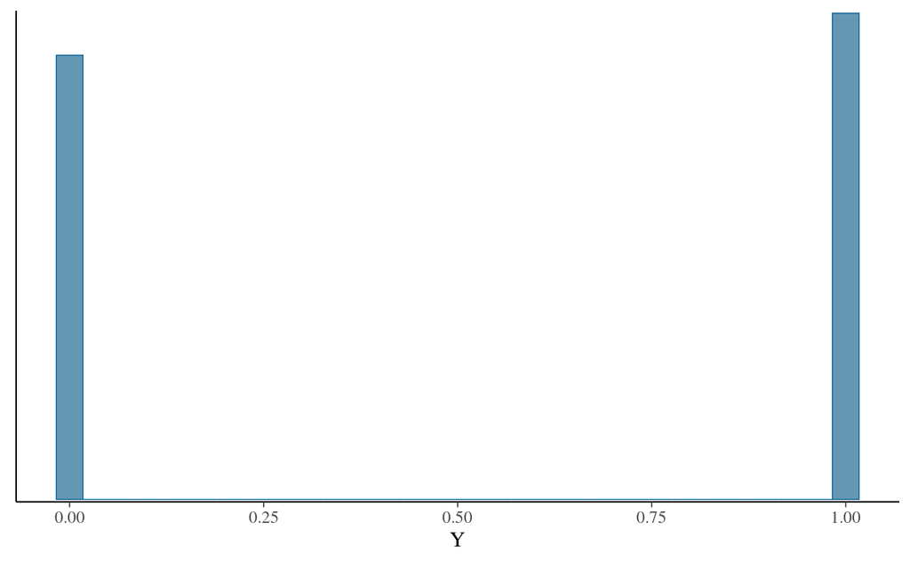

```r
#remaking the logistic model with unscaled data
unscaled_diabetes_logit <- stan_glm(reg_formula,
                             data = PimaIndiansDiabetes, family = binomial,
                             prior_intercept = normal(-0.72, 0.40),
                             prior = normal(0, 2.5, autoscale = TRUE),
                             chains = 4, iter = 5000*2, seed = 84735,
                             prior_PD = FALSE)
# Posterior predictions of binary outcome
set.seed(84735)

# Extract the mean values for other variables
mean_values <- colMeans(PimaIndiansDiabetes[, c("pregnant", "pressure", "triceps", "insulin", "mass", "pedigree", "age")])

# Create new data for prediction with glucose and mean values for other variables
new_data <- data.frame(
  glucose = 150,
  pregnant = mean_values["pregnant"],
  pressure = mean_values["pressure"],
  triceps = mean_values["triceps"],
  insulin = mean_values["insulin"],
  mass = mean_values["mass"],
  pedigree = mean_values["pedigree"],
  age = mean_values["age"]
)
# Obtain posterior predictions
binary_prediction <- posterior_predict(
  unscaled_diabetes_logit, newdata = new_data)

#Plot predictions
mcmc_hist(binary_prediction) +
  labs(x = "Y")
```

```r
# Summarize the posterior predictions of Y
table(binary_prediction)
```

```
binary_prediction
    0     1
 9548 10452
```

```r
#the proportion of these predictions for which Y=1
count <- sum(binary_prediction == 1)
N <- 20000
count/N
```

```
[1] 0.5226
```

### Model Evaluation

**Posterior Predictive Check**

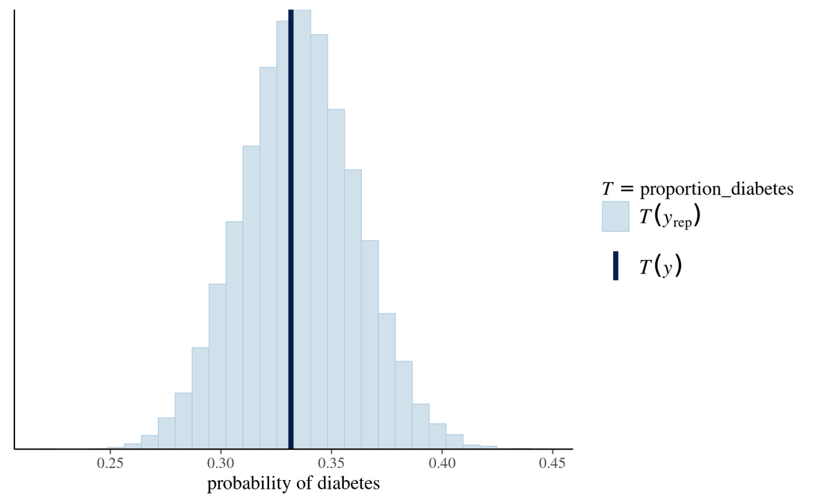

```r
#record the the proportion of subjects that have diabetes (Y=1) from each of 100 posterior simulated.
set.seed(123)
proportion_diabetes <- function(x){mean(x == 1)}
pp_check(unscaled_diabetes_logit, nreps = 100,
         plotfun = "stat", stat = "proportion_diabetes") +
  xlab("probability of diabetes")
```

Interpretation: Most of our posterior simulated datasets predicted diabetes on roughly 33% of subjects, close to the observed diabetes incidence in the PimaIndiansDiabetes data, yet some predicted diabetes for as few as 26% of subjects or as many as 42% of subjects.

**Classification Accuracy**

```r
set.seed(123)
classification_summary(model = unscaled_diabetes_logit, data = PimaIndiansDiabetes, cutoff = 0.5)
```

```
$confusion_matrix
 y   0  1
 0 233 29
 1  56 74

$accuracy_rates
```

| sensitivity | 0.5692308 |
| --- | --- |
| specificity | 0.8893130 |
| overall_accuracy | 0.7831633 |

```r
cv_accuracy_1 <- classification_summary_cv(
  model = unscaled_diabetes_logit, data = PimaIndiansDiabetes, cutoff = 0.35, k = 10)
cv_accuracy_1$cv
```

| sensitivity | specificity | overall_accuracy |
| --- | --- | --- |
| 0.7194406 | 0.7893826 | 0.7654487 |

```r
cv_accuracy_2 <- classification_summary_cv(
  model = unscaled_diabetes_logit, data = PimaIndiansDiabetes, cutoff = 0.2, k = 10)
cv_accuracy_2$cv
```

| sensitivity | specificity | overall_accuracy |
| --- | --- | --- |
| 0.8712938 | 0.6253273 | 0.7120513 |

```r
NA
```

Interpretation:  
True positive rate or sensitivity: Among the 130 subjects that do have diabetes, we correctly classified 74, or 56.92%  
True negative rate or specificity: Among the 262 subjects that don’t have diabetes, we correctly classified 233, or 88.93%  
Overall classification accuracy rate: We correctly classified 307 of the 392 total subjects (233+74 = 307), or 78.32%

Lowering the cutoff improved the sensitivity to 71.94% without comprimising the overall accuracy rate of the model (76.54%) or the specificity (78.93%) too much.

### Implementing naive Bayes classification:

```r
n_formula <- formula(paste("diabetes ~", paste(names(scaled_PIdiabetes)[1:8], collapse = " + ")))
naive_diabetes <- naiveBayes(n_formula, data = PimaIndiansDiabetes)

#lets classify the hypothetical new subject (new_data) we made before for the logistic classification model with glucose = 150 and all other variables equal to their column means.
predict(naive_diabetes, newdata = new_data, type = "raw")
```

```
           neg       pos
[1,] 0.7535576 0.2464424
```

```r
predict(naive_diabetes, newdata = new_data)
```

```
[1] neg
Levels: neg pos
```

Interesting! the logistic model classified the new subject as positive (prop=0.52) while the naive model classified the new subject as negative for diabetes by a greater prop (0.75).

**Evalating Naive bayes model accuracy:**

```r
PimaIndiansDiabetes <- PimaIndiansDiabetes %>%
  mutate(naive_class = predict(naive_diabetes, newdata = .))

# Confusion matrix for naive_model_1
PimaIndiansDiabetes %>%
  tabyl(diabetes, naive_class) %>%
  adorn_percentages("row") %>%
  adorn_pct_formatting(digits = 2) %>%
  adorn_ns()
```

```
 diabetes          neg         pos
      neg 83.97% (220) 16.03% (42)
      pos 34.62%  (45) 65.38% (85)
```

```r
#10-fold cross-validation to evaluate and compare how well our naive Bayes classification models classify new subjects, not just those in our sample
set.seed(84735)
cv_naive_accuracy <- naive_classification_summary_cv(
  model = naive_diabetes, data = PimaIndiansDiabetes, y = "diabetes", k = 10)
cv_naive_accuracy$cv
```

```
 diabetes          neg         pos
      neg 82.82% (217) 17.18% (45)
      pos 35.38%  (46) 64.62% (84)
```

The accuracy rates in this cross-validated confusion matrix are comparable to those in the non-cross-validated confusion matrix. This implies that our naive Bayes model appears to perform nearly as well on new subjects as it does on the original Pima Indians sample that we used to build this model. The highest overall accuracy is (220+85)/392 = 0.7780612, or 77.81%.

### Naive Bayes Classification vs Bayesian Logistic Classification

The highest overall model accuracies of both classification models were very close. The logit model at cutoff= 0.5 had an overall model accuracy of 78.32%, while the naive model had overall model accuracy of 77.81%.

The naive model would have been more useful if “diabetes” wasn’t a binary categorical response variable, since it can be used to classify categorical response variables with two or MORE categories.

The logistic model is much more tunable, since we can change the cutoff to improve sensitivty of specificity based on the needs of your model. For expample, the diabetes model would need a high sensitivity so the true positive rate can be higher and subjects will get the care that they need!

The Bayesian logistic regression provides coefficients for each predictor, which can help understand the impact of features on the outcome. Naive Bayes makes the naive assumption of independence between features, which can make the model less interpretable in terms of feature interactions.

### Decision Tree (interesting classification plot!)

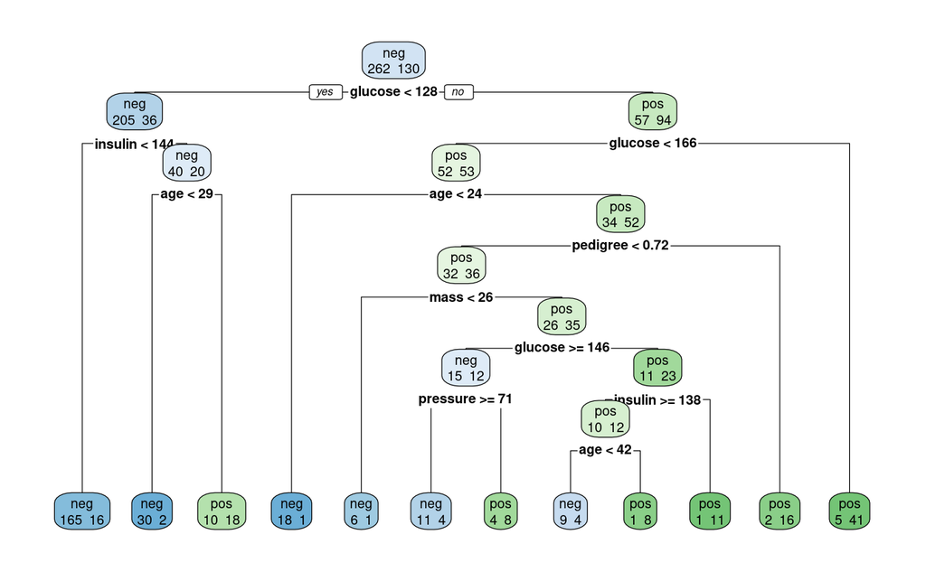

```r
# Create a decision tree model
decision_tree_model <- rpart(n_formula, data = PimaIndiansDiabetes, method = "class")

# Set up the plotting area with a larger size and adjust font size
par(mfrow = c(1, 1), mar = c(5, 5, 2, 1), cex.main = 0.8)

# Plot the decision tree
rpart.plot(decision_tree_model, tweak = 1.2, extra = 1)
```

**Predict with the tree**

```r
predict(decision_tree_model, newdata = new_data, type = "class")
```

```
pregnant
     pos
Levels: neg pos
```

```r
predict(decision_tree_model, newdata = new_data)
```

```
               neg       pos
pregnant 0.3333333 0.6666667
```

note: I dont know why is says pregnant but it should say diabetes.

The tree predicted postive diabetes diagnoses at prop = 0.667 comparable to the logistic model which predicted postive aswell at prop=0.5226.

**Evaluate model**

```r
# Confusion matrix for decision_tree_model
PimaIndiansDiabetes %>%
  tabyl(diabetes, tree_class) %>%
  adorn_percentages("row") %>%
  adorn_pct_formatting(digits = 2) %>%
  adorn_ns()
```

```
 diabetes          neg          pos
      neg 91.22% (239)  8.78%  (23)
      pos 21.54%  (28) 78.46% (102)
```

This is the best model by far! The sensitivity is high at 78.46% and the specificity is 91.22% The overall model accuracy is (239+102)/392 = 0.869898 or 87%!!!

I hypothezize the decision tree model performed better than the other models because it didn’t use pregnant and tricep skin thickness, after performing subset analysis and choosing the subset that maximizes information gain.

### Honor Pledge

**On my honor, I have neither received nor given any unauthorized assistance on this Project.**

- SIGNED: [Prisha Bhamre]